# STAT 5261 Final Project: AI & Microchip Technology Industry Asset Allocation with Risk Management

Group Members

2023-05-05

## 1. Summary

## 2. Descriptive Statistics

### Load libraires

```r
# Load necessary libraries
library(tidyverse)
```

```r
library(ggplot2)
library(dplyr)

library(stats)
library(tseries)
library(fGarch)
library(MASS)
library(VGAM)
library(extraDistr)
library(fitdistrplus)
library(Rsolnp)
library(metRology)
library(xts)
library(PerformanceAnalytics)
library(reshape2)
library(FactoMineR)
library(matrixStats)
library(psych)
library(rugarch)
library(copula)
library(xts)
library(Ecdat)
library(quadprog)
library(CVXR)
library(GGally)
library(FactoMineR)
```

### Read Dataset

```r
# Set Working Directory
setwd("C:\\Users\\Zhixing Zhou\\Desktop\\TC - Spring Courses\\STAT 5261 Statistical Methods for Finance\\Final Project")
# Read stock dataset
stock_data <- read_csv("ai_microchip_technology_stocks.csv") %>%
  mutate(Date = as.Date(Date, format = "%Y-%m-%d %H:%M:%S"))
# Read risk-free rate dataset
risk_free_data <- read_csv("bill-rates-2002-2021.csv") %>%
  mutate(Date = as.Date(Date, format = "%m/%d/%y"))
# Load S&P 500 data
sp500_data <- read_csv("sp500_monthly_returns_2015_2020.csv") %>%
  mutate(Date = as.Date(Date, format = "%m/%d/%y")) # "adj close" column is the return of S&P 500
# Calculate monthly returns
stock_data_xts <- xts::xts(stock_data[,-1], order.by = stock_data$Date)
monthly_returns <- PerformanceAnalytics::Return.calculate(stock_data_xts, method = "discrete") * 100


# Convert the S&P 500 data to xts format and calculate returns
sp500_xts <- xts(sp500_data[,-1], order.by = sp500_data$Date)
sp500_xts$`Adj Close`<-sp500_xts$`Adj Close`*100
# Combine asset returns and S&P 500 returns
combined_returns <- merge.xts(monthly_returns, sp500_xts )

colnames(combined_returns)[ncol(combined_returns)] <- "^GSPC" #What is "^GSPC" column useful for : it's ticket symbol for S&P 500 index

# Calculate normal returns for each column except Date and last column
stock_data_ret <- stock_data %>% dplyr::select(-Date) %>%  dplyr::mutate(dplyr::across(everything(), ~diff(.)/lag(.)))
stock_data_ret <- slice(stock_data_ret, 1:(nrow(stock_data_ret)-1))
# remove Date and last column # calculate normal returns

# Merge stock_data and sp500_data
#stock_data_with_sp500 <- merge(stock_data_ret, sp500_data)
monthly_returns_df <- data.frame(Date = index(monthly_returns), zoo::coredata(monthly_returns))
monthly_returns_df <- monthly_returns_df %>%
  mutate_at(vars(-1), ~./100) # divide by 100 except first column
monthly_returns_df <- slice(monthly_returns_df, 2:n())
stock_data_with_sp500 <- merge(sp500_data, monthly_returns_df, by = "Date")
```

### Calculate Descriptive Statistics

2.1 Report: sample statistics for each asset ( Means, Std. deviations, skewness, kurtosis, beta ) and S&P 500 equity curve for each asset and S&P 500 (a curve that shows the growth of a $1 in the asset over the time period)

Comment on the results: Comment Compare asset with S&P 500

2.2 Test for stationarity:

Fit Distributions: whether the assets’ returns look normally distributed, are there outliers in assets’ data, fit other distributions to the data , find out which one fits better

2.3 Sharpe’s Slope: sharpe’s slope for each asset, which asset has the highest slope

Comment on the sharpe ratio result?: (convert to annual sample means, annual sample standard deviation?) comment on the annual sample means and standard deviation?

```r
# Basic Descriptive Statistics
stats <- data.frame(Asset = colnames(combined_returns),
                    Mean = colMeans(combined_returns, na.rm = TRUE),
                    SD = apply(combined_returns, 2, sd, na.rm = TRUE),
                    Skewness = apply(combined_returns, 2, skewness, na.rm = TRUE),
                    Kurtosis = apply(combined_returns, 2, kurtosis, na.rm = TRUE))
```

```r
# Calculate beta for each asset
cov_matrix <- cov(combined_returns, use = "complete.obs")
beta <- cov_matrix / cov_matrix["^GSPC", "^GSPC"] # In regression, beta = Cov(X,Y)/ Var(X)
# # Add beta to the stats dataframe
stats$Beta <- beta[, "^GSPC"] # "^GSPC" is used to fill the betas

#Compute Sharpe's slope for each asset
#Monthly Risk-Free Rate = (1 + 0.0094)^(1/12) - 1 = 0.000776 or 0.0776%
# sharpe_slopes <- (stats$Mean - 0.000776) / stats$SD
# stats$sharpe_slopes <- sharpe_slopes
#Convert monthly sample means and SDs into annual estimates
stats$Annual_Mean <- stats$Mean * 12
stats$Annual_SD <- stats$SD * sqrt(12)
# Compute Sharpe ratios for each asset
sharpe_ratios <- (stats$Annual_Mean - 0.0094) / stats$Annual_SD
stats$Sharpe_Ratio <- sharpe_ratios
# Identify the asset with the highest Sharpe ratio
max_sharpe_asset <- stats[which.max(sharpe_ratios), "Asset"]
max_sharpe_ratio <- max(sharpe_ratios)
cat("The asset with the highest Sharpe ratio is", max_sharpe_asset, "with a Sharpe ratio of", max_sharpe_ratio, "\n")
```

```
## The asset with the highest Sharpe ratio is NVDA with a Sharpe ratio of 1.574634
```

[figure not shown]

```r
# Plot monthly returns
combined_returns_df <- data.frame(Date = index(combined_returns), zoo::coredata(combined_returns))
par(mfrow=c(4,4))
  for (asset in colnames(combined_returns_df[2:17])) {
    plot(combined_returns_df$Date, combined_returns_df[,asset], type = "l", pch = 19,
         col = "black", xlab = "Date", ylab = asset)
    title(paste("Monthly Returns of", asset))
  }
```

[figure not shown]

```r
par(mfrow=c(4,4))
  for (asset in colnames(combined_returns_df[2:17])) {
    hist(combined_returns_df[,asset], pch = 19,
         col = "black", xlab = asset, main = paste("Monthly Returns of", asset))
  }
```

[figure not shown]

```r
# Plot monthly prices

stock_data_df<-as.data.frame(stock_data)
par(mfrow=c(4,4))
for (asset in colnames(stock_data_df[2:16])) {
    plot(stock_data_df$Date, stock_data_df[,asset], type = "l", pch = 19,
         col = "black", xlab = "Date", ylab = asset)
    title(paste("Monthly Prices of", asset))
  }
```

[figure not shown]

```r
# Calculate equity curves
stock_data_with_sp500 <- stock_data_with_sp500[, -1]
equity_curves <- cumprod(1 + stock_data_with_sp500)


equity_curves_df <- data.frame(Date = index(equity_curves), coredata(equity_curves))

# Plot equity curves for each asset
equity_curves_df <- equity_curves_df %>% rename("^GSPC" = "Adj.Close")
par(mfrow=c(4,4))
for (asset in colnames(equity_curves_df[,2:17])) {
    plot(equity_curves_df$Date, equity_curves_df[,asset], type = "l", pch = 19,
         col = "black", xlab = "Date", ylab = asset)
   title(paste("Equity Curve of", asset))
  }
```

```r
#Test for stationarity: Augmented Dickey-Fuller test
stationarity_tests <- data.frame(Asset = colnames(combined_returns),
                                 stationary_p_value = apply(combined_returns, 2, function(x) adf.test(na.omit(x), alternative = "stationary")$p.value))
#the p-value returned by the test is less than a chosen significance level, then the null hypothesis of non-stationarity is rejected and the time series is considered stationary.

stationarity_tests_prt<- stationarity_tests%>% dplyr::select(-Asset)
round(stationarity_tests_prt, digits=4)
```

```
##       stationary_p_value
## ADI               0.0100
## AMD               0.0250
## ASML              0.0115
## AVGO              0.0122
## INTC              0.0120
## KLAC              0.0100
## LRCX              0.0323
## MCHP              0.0100
## MRVL              0.0235
## MU                0.1684
## NVDA              0.0321
## NXPI              0.0215
## QCOM              0.0100
## TSM               0.0164
## TXN               0.0589
## ^GSPC             0.0100
```

```r
#Fit different distributions to each set of returns

combined_returns_df2<- combined_returns_df[-1,-1]
data <-combined_returns_df2
dists <- c("norm", "t", "ged") # Normal, Student's t, and Generalized Error Distribution (GED)

fits <- matrix(NA, nrow = ncol(data), ncol = length(dists))
f_AIC <- matrix(NA, nrow = ncol(data), ncol = length(dists))
f_BIC <- matrix(NA, nrow = ncol(data), ncol = length(dists))
colnames(fits) <- dists
rownames(fits) <- colnames(data)
for (i in 1:ncol(data)) {
fit <- suppressWarnings(fitdistrplus::fitdist(data[,i], dists[1]))
fits[i,1] <- fit$loglik*-1

}


for (j in 1:ncol(data)) {
fit <- suppressWarnings(fitdistrplus::fitdist(data[,j], "t.scaled",
start=list(df=3,mean=mean(data[,j]),sd=sd(data[,j]))))
fits[j,2] <- fit$loglik*-1

}

for (k in 1:ncol(data)) {
loglik=function(beta) sum(-fGarch::dged(data[,k],mean=beta[1],sd=beta[2],nu=beta[3],log=TRUE))
start=c(mean(data[,k]),sd(data[,k]),1)
fit=optim(start,loglik,hessian=T,method='L-BFGS-B',lower=c(-0.1,0.01,1))
fits[k,3] <- fit$value

}

best <- as.data.frame(apply(fits, 1, which.max))
colnames(best)[1]<- "fit"
best$fit<- best$fit %>% dplyr::recode( '1'='normal','2'='t','3'='ged')
best
```

```
##           fit
## ADI         t
## AMD         t
## ASML        t
## AVGO   normal
## INTC   normal
## KLAC   normal
## LRCX   normal
## MCHP   normal
## MRVL   normal
## MU          t
## NVDA   normal
## NXPI        t
## QCOM   normal
## TSM    normal
## TXN         t
## X.GSPC normal
```

```r
#calculate VaR and ES (parametric, normal )

VaRnormalEqwt <- function(returnVector, prob=.05,
    notional=1, expected.return=mean(returnVector),
    digits=2)
{
  if(prob > .5) prob <- 1 - prob
  ans <- -qnorm(prob, mean=expected.return,
    sd=sd(returnVector)) * notional
  signif(ans, digits=digits)
}
ESnormalEqwt <- function(returnVector, prob=.05,
    notional=1, expected.return=mean(returnVector),
    digits=2)
{
  if(prob > .5) prob <- 1 - prob
  retsd <- sd(returnVector)
  v <- qnorm(prob, mean=expected.return, sd=retsd)
  tailExp <- integrate(function(x)
      x * dnorm(x, mean=expected.return, sd=retsd),
      -Inf, v)$value / prob
  ans <- -tailExp * notional
  signif(ans, digits=digits)
}
combined_returns_df3<- combined_returns_df[-1,-1]/100
VaR_pa<-sapply(combined_returns_df3 ,function(x){VaRnormalEqwt(x,prob=.05,digits=5,notional=100000)})
ES_pa<-sapply(combined_returns_df3 ,function(x){ESnormalEqwt(x,prob=.05,digits=5,notional=100000)})

VaR_pa
```

```
##     ADI     AMD    ASML    AVGO    INTC    KLAC    LRCX    MCHP    MRVL      MU
## 11064.0 21457.0  8964.4 10951.0 10604.0 12085.0 13139.0 13424.0 13378.0 18025.0
##    NVDA    NXPI    QCOM     TSM     TXN  X.GSPC
## 14469.0 14893.0 16730.0 10759.0  8451.2  6125.6
```

```r
ES_pa
```

```
##     ADI     AMD    ASML    AVGO    INTC    KLAC    LRCX    MCHP    MRVL      MU
## 14376.0 28568.0 11883.0 14401.0 13569.0 15828.0 17293.0 17394.0 17319.0 23134.0
##    NVDA    NXPI    QCOM     TSM     TXN  X.GSPC
## 19548.0 19062.0 21527.0 14214.0 11111.0  7932.7
```

```r
 #calculate VaR and ES (nonparametric, historical data )

VaRhistorical <- function(returnVector, prob=.05,
    notional=1, digits=2)
{
  if(prob > .5) prob <- 1 - prob
  ans <- -quantile(returnVector, prob) * notional
  signif(ans, digits=digits)
}
EShistorical <- function(returnVector, prob=.05,
    notional=1, digits=2)
{
  if(prob > .5) prob <- 1 - prob
  v <- quantile(returnVector, prob)
  ans <- -mean(returnVector[returnVector <= v]) *
      notional
  signif(ans, digits=digits)

}
combined_returns_df3<- combined_returns_df[-1,-1]/100
VaR_non<-sapply(combined_returns_df3 ,function(x){VaRhistorical(x,prob=.05,digits=5,notional=100000)})
ES_non<-sapply(combined_returns_df3 ,function(x){EShistorical(x,prob=.05,digits=5,notional=100000)})

VaR_non
```

```
##    ADI.5%    AMD.5%   ASML.5%   AVGO.5%   INTC.5%   KLAC.5%   LRCX.5%   MCHP.5%
##    9372.6   16438.0    8261.7    9482.0   12120.0    9779.9   13013.0    9122.7
##   MRVL.5%     MU.5%   NVDA.5%   NXPI.5%   QCOM.5%    TSM.5%    TXN.5% X.GSPC.5%
##   10603.0   18845.0   14683.0   12736.0   13812.0   10661.0    8295.5    6759.1
```

```r
ES_non
```

```
##     ADI     AMD    ASML    AVGO    INTC    KLAC    LRCX    MCHP    MRVL      MU
## 13481.0 25247.0  8676.6 13721.0 15395.0 13148.0 15524.0 17801.0 14169.0 24274.0
##    NVDA    NXPI    QCOM     TSM     TXN  X.GSPC
## 22713.0 18357.0 18096.0 12394.0 11526.0  9260.3
```

2.4 Display the result in a table.

```r
#print descriptive statistics
stats_prt<-round((stats%>% dplyr::select(-Asset,-Mean,-SD)), digits=4)
stats_prt$fit<- best$fit
stats_prt$VaR_pa<-VaR_pa
stats_prt$ES_pa<-ES_pa
stats_prt$VaR_non<-VaR_non
stats_prt$ES_non<-ES_non
stats_prt$stationary_p_value<-round(stationarity_tests_prt$stationary_p_value,digits=4)
stats_prt
```

```
##       Skewness Kurtosis   Beta Annual_Mean Annual_SD Sharpe_Ratio    fit
## ADI     0.0988  -0.0157 1.2484     23.6805   27.4571       0.8621      t
## AMD     0.0712  -0.1955 2.2362     78.4615   58.9583       1.3306      t
## ASML    0.3466  -0.5821 1.0688     30.2841   24.1942       1.2513      t
## AVGO    0.1891   0.7654 1.0395     31.5310   28.5968       1.1023 normal
## INTC   -0.4595   0.5429 0.7342     12.7864   24.5766       0.5199 normal
## KLAC    0.6457   1.6411 1.3693     31.7899   31.0296       1.0242 normal
## LRCX    0.0775   0.0978 1.4087     38.5784   34.4412       1.1198 normal
## MCHP    0.1063   1.0393 1.6178     26.4588   32.9138       0.8036 normal
## MRVL    0.4912   0.1836 1.1294     25.6107   32.6696       0.7836 normal
## MU     -0.2304  -0.0267 1.4975     25.0449   42.3567       0.5911      t
## NVDA   -0.0478   0.6978 1.3447     66.3176   42.1102       1.5746 normal
## NXPI   -0.1344  -0.0390 1.3586     18.2179   34.5614       0.5268      t
## QCOM    1.1637   4.1617 1.4549     25.8212   39.7655       0.6491 normal
## TSM     1.0421   4.3448 1.0428     34.1336   28.6482       1.1911 normal
## TXN    -0.1627  -0.2172 1.1069     24.2297   22.0508       1.0984      t
## ^GSPC  -0.3636   1.2825 1.0000     11.8526   14.9808       0.7906 normal
##        VaR_pa   ES_pa VaR_non  ES_non stationary_p_value
## ADI   11064.0 14376.0  9372.6 13481.0             0.0100
## AMD   21457.0 28568.0 16438.0 25247.0             0.0250
## ASML   8964.4 11883.0  8261.7  8676.6             0.0115
## AVGO  10951.0 14401.0  9482.0 13721.0             0.0122
## INTC  10604.0 13569.0 12120.0 15395.0             0.0120
## KLAC  12085.0 15828.0  9779.9 13148.0             0.0100
## LRCX  13139.0 17293.0 13013.0 15524.0             0.0323
## MCHP  13424.0 17394.0  9122.7 17801.0             0.0100
## MRVL  13378.0 17319.0 10603.0 14169.0             0.0235
## MU    18025.0 23134.0 18845.0 24274.0             0.1684
## NVDA  14469.0 19548.0 14683.0 22713.0             0.0321
## NXPI  14893.0 19062.0 12736.0 18357.0             0.0215
## QCOM  16730.0 21527.0 13812.0 18096.0             0.0100
## TSM   10759.0 14214.0 10661.0 12394.0             0.0164
## TXN    8451.2 11111.0  8295.5 11526.0             0.0589
## ^GSPC  6125.6  7932.7  6759.1  9260.3             0.0100
```

```r
write.csv(stats_prt,file="2 descriptive stat.csv")
```

## 3. Portfolio Theory

### Calculate Covariance Matrix of Assets

[figure not shown]

```r
#Sample covariance matrix of asset returns
cov_matrix <- cov(na.omit(monthly_returns))
#print(cov_matrix)
#Pairwise scatter plots
# Pairwise scatter plots between asset returns
pairs_plot <- ggpairs(as.data.frame(na.omit(monthly_returns)))
print(pairs_plot)
```

### Calculate Portfolios

3.1 Minimum Variance Portfolio( not allow short selling): Compute MVP , estimate its mean, std. deviation of return, VaR, ES (annualize the monthly mean return and the risk)

Comment: weights of the portfolio comment on mean return and risk of the portfolio relative to those of each asset

VaR: calculate 5% VAR of $100000 investment over a month, compare to VaR of individual assets

3.2 Minimum Variance Portfolio (allow short selling): Compute MVP , estimate its mean, std. deviation of return, VaR, ES (annualize the monthly mean return and the risk)

Comment: weights of the portfolio comment on mean return and risk of the portfolio relative to those of each asset

VaR: calculate 5% VAR of $100000 investment over a month, compare to VaR of individual assets

3.3 Efficient frontier of the portfolio (allow and not allow short selling): calculate efficient frontier using estimated means , variances and covariances

compare sharpe ratio of each asset and tangency portfolio using markowitz approach

3.4 tangency portfolio(not allow short selling): compute tangency portfolio, its expected return, and std. deviation, and sharpe ratios

```r
#portfolios that doesn't allow short selling , with monthly data

#mean_vect=c(0.0427,0.0015,0.0285)
mean_vect=as.vector(stats$Mean[1:15])/100
#cov_mat=matrix(c(0.01,0.0018,0.0011,0.0018,(0.1044)^2,0.0026,0.0011,0.0026,(0.1411)^2),nrow=3,ncol=3,byrow=TRUE)
cov_mat=cov(na.omit(monthly_returns)/100)
#sd_vect = sqrt(diag(cov_mat))
sd_vect = as.vector(stats$SD[1:15])/100
```

```r
##efficient frontier  (efficient and inefficient portfolios)
library(Ecdat)
library(quadprog)
Amat = cbind(rep(1,15),mean_vect,diag(1,nrow=15))  # set the constraints matrix # how to write Amat
muP = seq(min(mean_vect)+0.0001,max(mean_vect)-0.0001,length=300)  # set of 300 possible target values  for the expect portfolio return
sdP = muP # set up storage for std dev's of portfolio returns
weights = matrix(0,nrow=300,ncol=15) #storage for portfolio weights
for (i in 1:length(muP))
{
  bvec = c(1,muP[i],rep(-0,15))  # constraint vector
  result =
    solve.QP(Dmat=2*cov_mat,dvec=rep(0,15),Amat=Amat,bvec=bvec,meq=2)
  sdP[i] = sqrt(result$value)
  weights[i,] = result$solution
}
#find the optimal portfolios for each target expected return # How is this calculated? # how to write bvec
#?solve.QP #Solve a Quadratic Programming Problem
par(mfrow = c(1,1))
##plot efficient frontier
plot(sdP,muP,type="l",xlim=c(0,0.5),ylim=c(0,.08),lty=3)  #  plot the efficient frontier (and inefficient portfolios below the min var portfolio)

mufree = 0.000776 # input value of risk-free interest rate
#points(0,mufree,cex=4,pch="*")  # show risk-free asset

#tangency portfolio
#?points #points(x, y = NULL, type = "p", ...)
sharpe =( muP-mufree)/sdP # compute Sharpe's ratios, also the slope of line between the point of portfolio and point of risk free asset
ind = (sharpe == max(sharpe)) # Find maximum Sharpe's ratio
options(digits=5)
muP[ind]
```

```
## [1] 0.042306
```

```r
weights[ind,] #  print the weights of the tangency portfolio #tangency portfolio
```

```
##  [1]  1.2589e-16  1.6728e-01  2.1836e-01  1.4510e-01  1.5330e-16 -2.8461e-17
##  [7]  3.5357e-02 -1.8606e-16 -4.3967e-18 -2.9050e-17  3.1938e-01 -1.1287e-16
## [13] -3.3141e-17  1.1451e-01 -7.5088e-18
```

```r
# tangency_no_short<-as.list(c(muP[ind]*12,sdP[ind]*sqrt(12),weights[ind,]))
# names(tangency_no_short)<- c("Annual_Mean","Annual_SD",names(monthly_returns))
# tangency_no_short

#3.1
#minimum variance portfolio
ind2 = (sdP == min(sdP)) # find the minimum variance portfolio
weights[ind2,]
```

```
##  [1]  3.5627e-17  2.2574e-19  5.1988e-02  5.4295e-02  3.5323e-01  3.5430e-17
##  [7] -2.0658e-17 -1.5174e-17  8.1721e-02 -1.9521e-17 -8.6642e-19 -4.2695e-18
## [13]  3.0896e-19  2.2017e-01  2.3860e-01
```

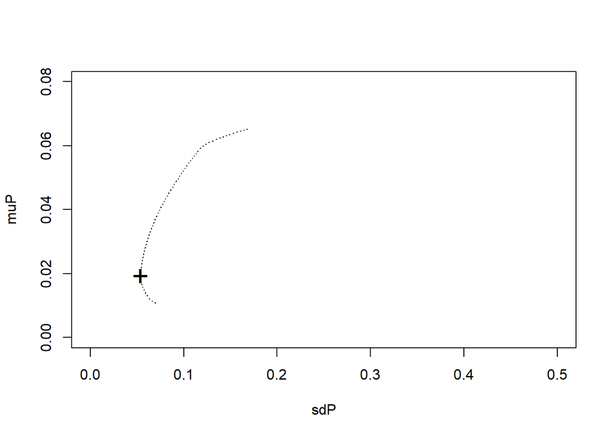

```r
points(sdP[ind2],muP[ind2],cex=2,pch="+") # show min var portfolio
```

```r
muP[ind2]
```

```
## [1] 0.019327
```

```r
(sdP[ind2])^2
```

```
## [1] 0.0029072
```

```r
#calculate VaR and ES (nonparametric, historical data )
VaRnormalEqwt1 <- function(sd=sd, prob=.05,
    notional=1, mean=mean,
    digits=2)
{
  if(prob > .5) prob <- 1 - prob
  ans <- -qnorm(prob, mean=mean,
    sd=sd) * notional
  signif(ans, digits=digits)
}
ESnormalEqwt1 <- function(sd=sd, prob=.05,
    notional=1, mean=mean,
    digits=2)
{
  if(prob > .5) prob <- 1 - prob
  v <- qnorm(prob, mean=mean, sd=sd)
  tailExp <- integrate(function(x)
      x * dnorm(x, mean=mean, sd=sd),
      -Inf, v)$value / prob
  ans <- -tailExp * notional
  signif(ans, digits=digits)
}
VaR1<-VaRnormalEqwt1(sd=sdP[ind],prob=.05,notional = 100000, mean=muP[ind],digits=5)
ES1<-ESnormalEqwt1(sd=sdP[ind],prob=.05,notional = 100000, mean=muP[ind],digits=5)
print("Tangency Portfolio without Shorting")
```

```
## [1] "Tangency Portfolio without Shorting"
```

```r
df_tan_no_short<-c(muP[ind]*12,sdP[ind]*sqrt(12),VaR1,ES1,weights[ind,],sharpe[ind]*sqrt(12))
names(df_tan_no_short)<-c("Annual_Mean","Annual_SD","VaR_non","ES_non",names(monthly_returns),"Sharpe_Ratio")
round(df_tan_no_short,4)
```

```
##  Annual_Mean    Annual_SD      VaR_non       ES_non          ADI          AMD
##       0.5077       0.2720    8683.0000   11964.0000       0.0000       0.1673
##         ASML         AVGO         INTC         KLAC         LRCX         MCHP
##       0.2184       0.1451       0.0000       0.0000       0.0354       0.0000
##         MRVL           MU         NVDA         NXPI         QCOM          TSM
##       0.0000       0.0000       0.3194       0.0000       0.0000       0.1145
##          TXN Sharpe_Ratio
##       0.0000       1.8324
```

```r
VaR2<-VaRnormalEqwt1(sd=sdP[ind2],prob=.05,notional = 100000, mean=muP[ind2],digits=5)
ES2<-ESnormalEqwt1(sd=sdP[ind2],prob=.05,notional = 100000, mean=muP[ind2],digits=5)
print("MVP without Shorting")
```

```
## [1] "MVP without Shorting"
```

```r
df_mvp_no_short<-c(muP[ind2]*12,sdP[ind2]*sqrt(12),VaR2,ES2,weights[ind2,],sharpe[ind2]*sqrt(12))
names(df_mvp_no_short)<-c("Annual_Mean","Annual_SD","VaR_non","ES_non",names(monthly_returns),"Sharpe_Ratio")
round(df_mvp_no_short,4)
```

```
##  Annual_Mean    Annual_SD      VaR_non       ES_non          ADI          AMD
##       0.2319       0.1868    6936.2000    9189.2000       0.0000       0.0000
##         ASML         AVGO         INTC         KLAC         LRCX         MCHP
##       0.0520       0.0543       0.3532       0.0000       0.0000       0.0000
##         MRVL           MU         NVDA         NXPI         QCOM          TSM
##       0.0817       0.0000       0.0000       0.0000       0.0000       0.2202
##          TXN Sharpe_Ratio
##       0.2386       1.1918
```

```r
#plotting
#lines(c(0,sdP[ind]),c(mufree,muP[ind]),col="red",lwd=3)
plot(sdP,muP,type="l",xlim=c(0,0.5),ylim=c(0,.08),lty=3)
lines(c(0,2.5),mufree+c(0,2.5)*(muP[ind]-mufree)/sdP[ind],lwd=4,lty=1, col = "blue")
#  plot the efficient frontier (and inefficient portfolios below the min var portfolio)
# (0,mufree), (2,y) where (2,y) is on the line of tangency portfolio
#?lines
# show line of optimal portfolio
points(sdP[ind],muP[ind],cex=4,pch="*") # show tangency portfolio
#minimum variance portfolio
ind2 <- (sdP == min(sdP)) # find the minimum variance portfolio
muP[ind2]
```

```
## [1] 0.019327
```

```r
weights[ind2,]
```

```
##  [1]  3.5627e-17  2.2574e-19  5.1988e-02  5.4295e-02  3.5323e-01  3.5430e-17
##  [7] -2.0658e-17 -1.5174e-17  8.1721e-02 -1.9521e-17 -8.6642e-19 -4.2695e-18
## [13]  3.0896e-19  2.2017e-01  2.3860e-01
```

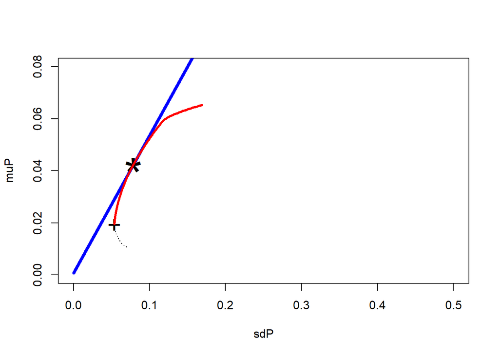

```r
points(sdP[ind2],muP[ind2],cex=2,pch="+") # show min var portfolio

#efficient frontier (efficient portfolios)
ind3 <- (muP > muP[ind2])
front<-weights[ind3,]
#head(front)
lines(sdP[ind3],muP[ind3],type="l",xlim=c(0,.25),
      ylim=c(0,.3),lwd=3, col = "red")  #  plot the efficient frontier
```

```r
#location of risky assets
#?lines # xlim ylim set x and y axis limits
# text(sd_vect[1],mean_vect[1],"GM",cex=1.15)
# text(sd_vect[2],mean_vect[2],"F",cex=1.15)
# text(sd_vect[3],mean_vect[3],"CAT",cex=1.15)
# text(sd_vect[4],mean_vect[4],"UTX",cex=1.15)
# text(sd_vect[5],mean_vect[5],"MRK",cex=1.15)
# text(sd_vect[6],mean_vect[6],"IBM",cex=1.15)
#graphics.off()
```

### Calculate portfolios that allow short selling , with monthly data

```r
# no constraints for percentage of asset and allow infinite short selling, devide muP into 10000 parts
#mean_vect=c(0.0427,0.0015,0.0285)
mean_vect=as.vector(stats$Mean[1:15])/100
#cov_mat=matrix(c(0.01,0.0018,0.0011,0.0018,(0.1044)^2,0.0026,0.0011,0.0026,(0.1411)^2),nrow=3,ncol=3,byrow=TRUE)
cov_mat=cov(na.omit(monthly_returns)/100)
#sd_vect = sqrt(diag(cov_mat))
sd_vect = as.vector(stats$SD[1:15])/100

options(digits=5)
library(Ecdat)
library(quadprog)
Amat = cbind(rep(1,15),mean_vect)  # set the constraints matrix # how to write Amat # no short selling to be set here at 0
muP = seq(0,0.1,length=100000)  # set of possible target values  for the expect portfolio return # no short selling to be set here roughly at min(mean_vect) and max(mean_vect)
sdP = muP # set up storage for std dev's of portfolio returns
weights = matrix(0,nrow=100000,ncol=15) #storage for portfolio weights
for (i in 1:length(muP))
{
  bvec = c(1,muP[i])  # constraint vector # no short selling to be set here at 1
  result =
    solve.QP(Dmat=2*cov_mat,dvec=rep(0,15),Amat=Amat,bvec=bvec,meq=2)
  sdP[i] = sqrt(result$value)
  weights[i,] = result$solution
}

#find the optimal portfolios for each target expected return # How is this calculated? # how to write bvec
#?solve.QP #Solve a Quadratic Programming Problem
par(mfrow = c(1,1))
##plot efficient frontier
plot(sdP,muP,type="l",xlim=c(0,0.5),ylim=c(0,.08),lty=3)  #  plot the efficient frontier (and inefficient portfolios below the min var portfolio)

mufree = 0.000776 # input value of risk-free interest rate
#points(0,mufree,cex=4,pch="*")  # show risk-free asset

#tangency portfolio
#?points #points(x, y = NULL, type = "p", ...)
sharpe =( muP-mufree)/sdP # compute Sharpe's ratios, also the slope of line between the point of portfolio and point of risk free asset
ind = (sharpe == max(sharpe)) # Find maximum Sharpe's ratio
options(digits=5)
muP[ind]
```

```
## [1] 0.050263
```

```r
weights[ind,] #  print the weights of the tangency portfolio #tangency portfolio
```

```
##  [1]  0.0090377  0.1361290  0.4552790  0.3777144 -0.2414873 -0.0961981
##  [7]  0.4334026 -0.5272221 -0.0514483 -0.2466458  0.3656818 -0.1521459
## [13] -0.1134344  0.0263561  0.6249814
```

```r
#3.1
#minimum variance portfolio
ind2 = (sdP == min(sdP)) # find the minimum variance portfolio
weights[ind2,]
```

```
##  [1]  0.1502327  0.0084578  0.1550049  0.0704042  0.3549123 -0.1212873
##  [7]  0.1020717 -0.4650211  0.1069740 -0.1011181 -0.0735589 -0.0186533
## [13]  0.0067254  0.2156647  0.6091910
```

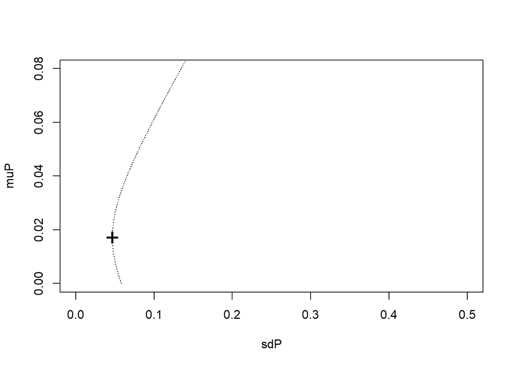

```r
points(sdP[ind2],muP[ind2],cex=2,pch="+") # show min var portfolio
```

```r
muP[ind2]
```

```
## [1] 0.01728
```

```r
(sdP[ind2])^2
```

```
## [1] 0.0021954
```

```r
#calculate VaR and ES (nonparametric, historical data )
VaRnormalEqwt1 <- function(sd=sd, prob=.05,
    notional=1, mean=mean,
    digits=2)
{
  if(prob > .5) prob <- 1 - prob
  ans <- -qnorm(prob, mean=mean,
    sd=sd) * notional
  signif(ans, digits=digits)
}
ESnormalEqwt1 <- function(sd=sd, prob=.05,
    notional=1, mean=mean,
    digits=2)
{
  if(prob > .5) prob <- 1 - prob
  v <- qnorm(prob, mean=mean, sd=sd)
  tailExp <- integrate(function(x)
      x * dnorm(x, mean=mean, sd=sd),
      -Inf, v)$value / prob
  ans <- -tailExp * notional
  signif(ans, digits=digits)
}
VaR1<-VaRnormalEqwt1(sd=sdP[ind],prob=.05,notional = 100000, mean=muP[ind],digits=5)
ES1<-ESnormalEqwt1(sd=sdP[ind],prob=.05,notional = 100000, mean=muP[ind],digits=5)
print("Tangency Portfolio with Shorting")
```

```
## [1] "Tangency Portfolio with Shorting"
```

```r
df_tan_short<-c(muP[ind]*12,sdP[ind]*sqrt(12),VaR1,ES1,weights[ind,],sharpe[ind]*sqrt(12))
names(df_tan_short)<-c("Annual_Mean","Annual_SD","VaR_non","ES_non",names(monthly_returns),"Sharpe_Ratio")
round(df_tan_short,4)
```

```
##  Annual_Mean    Annual_SD      VaR_non       ES_non          ADI          AMD
##       0.6032       0.2811    8318.9000   11709.0000       0.0090       0.1361
##         ASML         AVGO         INTC         KLAC         LRCX         MCHP
##       0.4553       0.3777      -0.2415      -0.0962       0.4334      -0.5272
##         MRVL           MU         NVDA         NXPI         QCOM          TSM
##      -0.0514      -0.2466       0.3657      -0.1521      -0.1134       0.0264
##          TXN Sharpe_Ratio
##       0.6250       2.1129
```

```r
VaR2<-VaRnormalEqwt1(sd=sdP[ind2],prob=.05,notional = 100000, mean=muP[ind2],digits=5)
ES2<-ESnormalEqwt1(sd=sdP[ind2],prob=.05,notional = 100000, mean=muP[ind2],digits=5)
print("MVP with Shorting")
```

```
## [1] "MVP with Shorting"
```

```r
df_mvp_short<-c(muP[ind2]*12,sdP[ind2]*sqrt(12),VaR2,ES2,weights[ind2,],sharpe[ind2]*sqrt(12))
names(df_mvp_short)<-c("Annual_Mean","Annual_SD","VaR_non","ES_non",names(monthly_returns),"Sharpe_Ratio")
round(df_mvp_short,4)
```

```
##  Annual_Mean    Annual_SD      VaR_non       ES_non          ADI          AMD
##       0.2074       0.1623    5978.9000    7936.8000       0.1502       0.0085
##         ASML         AVGO         INTC         KLAC         LRCX         MCHP
##       0.1550       0.0704       0.3549      -0.1213       0.1021      -0.4650
##         MRVL           MU         NVDA         NXPI         QCOM          TSM
##       0.1070      -0.1011      -0.0736      -0.0187       0.0067       0.2157
##          TXN Sharpe_Ratio
##       0.6092       1.2202
```

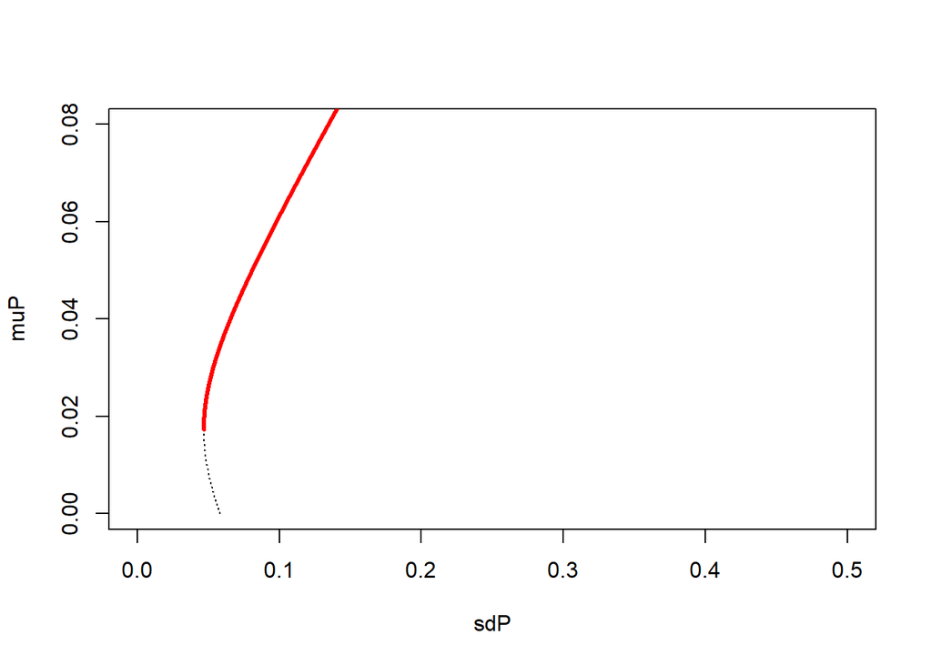

```r
#plotting
#efficient frontier (efficient portfolios)
ind3 = (muP > muP[ind2])
front<-weights[ind3,]
#head(front)  #  plot the efficient frontier (and inefficient portfolios below the min var portfolio)
plot(sdP,muP,type="l",xlim=c(0,0.5),ylim=c(0,.08),lty=3)
lines(sdP[ind3],muP[ind3],type="l",xlim=c(0,.25),
      ylim=c(0,.3),lwd=3, col = "red")  #  plot the efficient frontier
```

```r
# #efficient portfolio of  muP=0.0427
# ind4= (0.0426995 < muP & muP < 0.0427005)
# muP[ind4]
# weights[ind4,]
# sdP[ind4]
mufree = 0.000776 # input value of risk-free interest rate
#points(0,mufree,cex=4,pch="*")  # show risk-free asset

#tangency portfolio
#?points #points(x, y = NULL, type = "p", ...)
sharpe =( muP-mufree)/sdP # compute Sharpe's ratios, also the slope of line between the point of portfolio and point of risk free asset
ind = (sharpe == max(sharpe)) # Find maximum Sharpe's ratio
options(digits=5)
weights[ind,] #  print the weights of the tangency portfolio #tangency portfolio
```

```
##  [1]  0.0090377  0.1361290  0.4552790  0.3777144 -0.2414873 -0.0961981
##  [7]  0.4334026 -0.5272221 -0.0514483 -0.2466458  0.3656818 -0.1521459
## [13] -0.1134344  0.0263561  0.6249814
```

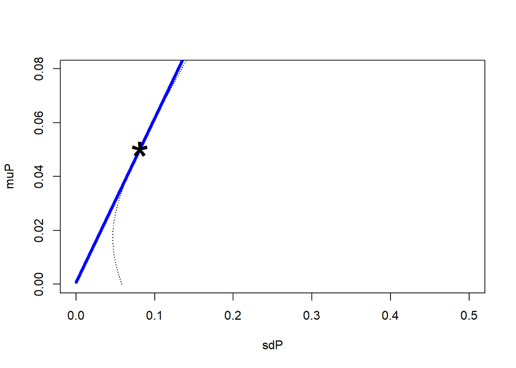

```r
#lines(c(0,sdP[ind]),c(mufree,muP[ind]),col="red",lwd=3)
plot(sdP,muP,type="l",xlim=c(0,0.5),ylim=c(0,.08),lty=3)  #  plot the efficient frontier (and inefficient portfolios below the min var portfolio)
lines(c(0,2.5),mufree+c(0,2.5)*(muP[ind]-mufree)/sdP[ind],lwd=4,lty=1, col = "blue") # (0,mufree), (2,y) where (2,y) is on the line of tangency portfolio
points(sdP[ind],muP[ind],cex=4,pch="*") # show tangency portfolio
```

3.4 Show the result: show the weights and statistics of each portfolio in tables

```r
portfolio_prt<- as.data.frame(cbind(df_mvp_no_short,df_tan_no_short,df_mvp_short,df_tan_short))
round(portfolio_prt,4)
```

```
##              df_mvp_no_short df_tan_no_short df_mvp_short df_tan_short
## Annual_Mean           0.2319          0.5077       0.2074       0.6032
## Annual_SD             0.1868          0.2720       0.1623       0.2811
## VaR_non            6936.2000       8683.0000    5978.9000    8318.9000
## ES_non             9189.2000      11964.0000    7936.8000   11709.0000
## ADI                   0.0000          0.0000       0.1502       0.0090
## AMD                   0.0000          0.1673       0.0085       0.1361
## ASML                  0.0520          0.2184       0.1550       0.4553
## AVGO                  0.0543          0.1451       0.0704       0.3777
## INTC                  0.3532          0.0000       0.3549      -0.2415
## KLAC                  0.0000          0.0000      -0.1213      -0.0962
## LRCX                  0.0000          0.0354       0.1021       0.4334
## MCHP                  0.0000          0.0000      -0.4650      -0.5272
## MRVL                  0.0817          0.0000       0.1070      -0.0514
## MU                    0.0000          0.0000      -0.1011      -0.2466
## NVDA                  0.0000          0.3194      -0.0736       0.3657
## NXPI                  0.0000          0.0000      -0.0187      -0.1521
## QCOM                  0.0000          0.0000       0.0067      -0.1134
## TSM                   0.2202          0.1145       0.2157       0.0264
## TXN                   0.2386          0.0000       0.6092       0.6250
## Sharpe_Ratio          1.1918          1.8324       1.2202       2.1129
```

```r
write.csv(round(portfolio_prt,4),"3 portfolio_prt.csv")
```

## 4. Asset Allocation

### Calculate portfolios that doesn’t allow short selling , with monthly data

```r
#portfolios that doesn't allow short selling , with monthly data

#mean_vect=c(0.0427,0.0015,0.0285)
mean_vect=as.vector(stats$Mean[1:15])/100
#cov_mat=matrix(c(0.01,0.0018,0.0011,0.0018,(0.1044)^2,0.0026,0.0011,0.0026,(0.1411)^2),nrow=3,ncol=3,byrow=TRUE)
cov_mat=cov(na.omit(monthly_returns)/100)
#sd_vect = sqrt(diag(cov_mat))
sd_vect = as.vector(stats$SD[1:15])/100
```

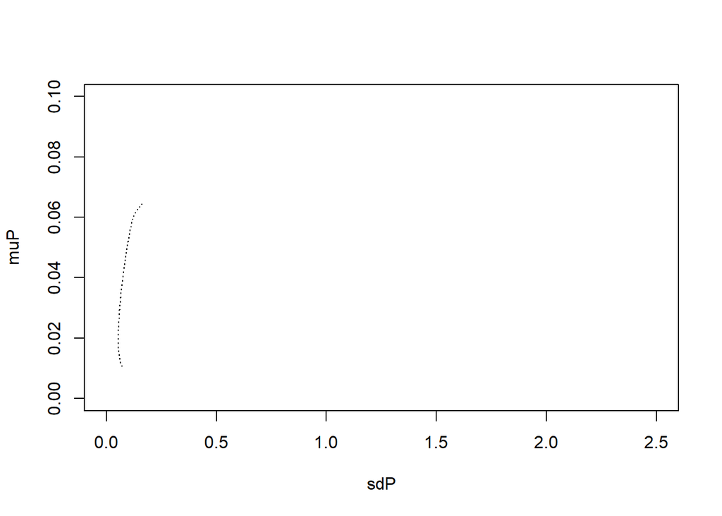

```r
##efficient frontier  (efficient and inefficient portfolios)
library(Ecdat)
library(quadprog)
Amat = cbind(rep(1,15),mean_vect,diag(1,nrow=15))  # set the constraints matrix # how to write Amat
muP = seq(min(mean_vect)+0.0001,max(mean_vect)-0.0001,length=300)  # set of 300 possible target values  for the expect portfolio return
sdP = muP # set up storage for std dev's of portfolio returns
weights = matrix(0,nrow=300,ncol=15) #storage for portfolio weights
for (i in 1:length(muP))
{
  bvec = c(1,muP[i],rep(-0,15))  # constraint vector
  result =
    solve.QP(Dmat=2*cov_mat,dvec=rep(0,15),Amat=Amat,bvec=bvec,meq=2)
  sdP[i] = sqrt(result$value)
  weights[i,] = result$solution
}
#find the optimal portfolios for each target expected return # How is this calculated? # how to write bvec
#?solve.QP #Solve a Quadratic Programming Problem
par(mfrow = c(1,1))
##plot efficient frontier
plot(sdP,muP,type="l",xlim=c(0,2.5),ylim=c(0,.10),lty=3)  #  plot the efficient frontier (and inefficient portfolios below the min var portfolio)
```

```r
mufree = 0.000776 # input value of risk-free interest rate
#points(0,mufree,cex=4,pch="*")  # show risk-free asset

#tangency portfolio
#?points #points(x, y = NULL, type = "p", ...)
sharpe =( muP-mufree)/sdP # compute Sharpe's ratios, also the slope of line between the point of portfolio and point of risk free asset
ind = (sharpe == max(sharpe)) # Find maximum Sharpe's ratio
options(digits=5)
muP[ind]
```

```
## [1] 0.042306
```

```r
weights[ind,] #  print the weights of the tangency portfolio #tangency portfolio
```

```
##  [1]  1.2589e-16  1.6728e-01  2.1836e-01  1.4510e-01  1.5330e-16 -2.8461e-17
##  [7]  3.5357e-02 -1.8606e-16 -4.3967e-18 -2.9050e-17  3.1938e-01 -1.1287e-16
## [13] -3.3141e-17  1.1451e-01 -7.5088e-18
```

```r
#lines(c(0,sdP[ind]),c(mufree,muP[ind]),col="red",lwd=3)
plot(sdP,muP,type="l",xlim=c(0,2.5),ylim=c(0,.10),lty=3)
lines(c(0,2.5),mufree+c(0,2.5)*(muP[ind]-mufree)/sdP[ind],lwd=4,lty=1, col = "blue")
#  plot the efficient frontier (and inefficient portfolios below the min var portfolio)
# (0,mufree), (2,y) where (2,y) is on the line of tangency portfolio
#?lines
# show line of optimal portfolio
points(sdP[ind],muP[ind],cex=4,pch="*") # show tangency portfolio
#minimum variance portfolio
ind2 <- (sdP == min(sdP)) # find the minimum variance portfolio
muP[ind2]
```

```
## [1] 0.019327
```

```r
weights[ind2,]
```

```
##  [1]  3.5627e-17  2.2574e-19  5.1988e-02  5.4295e-02  3.5323e-01  3.5430e-17
##  [7] -2.0658e-17 -1.5174e-17  8.1721e-02 -1.9521e-17 -8.6642e-19 -4.2695e-18
## [13]  3.0896e-19  2.2017e-01  2.3860e-01
```

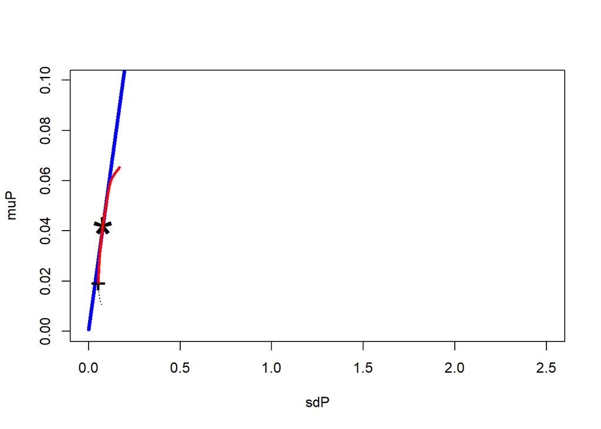

```r
points(sdP[ind2],muP[ind2],cex=2,pch="+") # show min var portfolio

#efficient frontier (efficient portfolios)
ind3 <- (muP > muP[ind2])
front<-weights[ind3,]
#head(front)
lines(sdP[ind3],muP[ind3],type="l",xlim=c(0,.25),
      ylim=c(0,.3),lwd=3, col = "red")  #  plot the efficient frontier
```

```r
#location of risky assets
#?lines # xlim ylim set x and y axis limits
# text(sd_vect[1],mean_vect[1],"GM",cex=1.15)
# text(sd_vect[2],mean_vect[2],"F",cex=1.15)
# text(sd_vect[3],mean_vect[3],"CAT",cex=1.15)
# text(sd_vect[4],mean_vect[4],"UTX",cex=1.15)
# text(sd_vect[5],mean_vect[5],"MRK",cex=1.15)
# text(sd_vect[6],mean_vect[6],"IBM",cex=1.15)
#graphics.off()
```

### Calculation of efficient portfolio that has certain return with or without risk free assets

```r
R_P= 0.005
# R_P=w*mufree+(1-w)*muP[ind]
#w=(R_P-muP[ind]) / (mufree-muP[ind])
w= 0
#solve w
effi<-c((1-w)*weights[ind,])
names(effi)<-colnames(monthly_returns)
print(effi)
```

```
##         ADI         AMD        ASML        AVGO        INTC        KLAC
##  1.2589e-16  1.6728e-01  2.1836e-01  1.4510e-01  1.5330e-16 -2.8461e-17
##        LRCX        MCHP        MRVL          MU        NVDA        NXPI
##  3.5357e-02 -1.8606e-16 -4.3967e-18 -2.9050e-17  3.1938e-01 -1.1287e-16
##        QCOM         TSM         TXN
## -3.3141e-17  1.1451e-01 -7.5088e-18
```

```r
sum(effi)
```

```
## [1] 1
```

```r
#find efficient portfolio
sd_P=(1-w)*sdP[ind]
sd_P
```

```
## [1] 0.078509
```

```r
#calculate VaR and ES (nonparametric, historical data )
VaRnormalEqwt1 <- function(sd=sd, prob=.05,
    notional=1, mean=mean,
    digits=2)
{
  if(prob > .5) prob <- 1 - prob
  ans <- -qnorm(prob, mean=mean,
    sd=sd) * notional
  signif(ans, digits=digits)
}
ESnormalEqwt1 <- function(sd=sd, prob=.05,
    notional=1, mean=mean,
    digits=2)
{
  if(prob > .5) prob <- 1 - prob
  v <- qnorm(prob, mean=mean, sd=sd)
  tailExp <- integrate(function(x)
      x * dnorm(x, mean=mean, sd=sd),
      -Inf, v)$value / prob
  ans <- -tailExp * notional
  signif(ans, digits=digits)
}
VaR1<-VaRnormalEqwt1(sd=sd_P,prob=.05,notional = 100000, mean=R_P,digits=5)
ES1<-ESnormalEqwt1(sd=sd_P,prob=.05,notional = 100000, mean=R_P,digits=5)

df_risky<-c(R_P*12,sd_P*sqrt(12),VaR1,ES1,0,effi)
names(df_risky)<-c("Annual_Mean","Annual_SD","VaR_non","ES_non","riskfree",names(effi))
df_risky
```

```
## Annual_Mean   Annual_SD     VaR_non      ES_non    riskfree         ADI
##  6.0000e-02  2.7196e-01  1.2414e+04  1.5694e+04  0.0000e+00  1.2589e-16
##         AMD        ASML        AVGO        INTC        KLAC        LRCX
##  1.6728e-01  2.1836e-01  1.4510e-01  1.5330e-16 -2.8461e-17  3.5357e-02
##        MCHP        MRVL          MU        NVDA        NXPI        QCOM
## -1.8606e-16 -4.3967e-18 -2.9050e-17  3.1938e-01 -1.1287e-16 -3.3141e-17
##         TSM         TXN
##  1.1451e-01 -7.5088e-18
```

4.2 Calculate the efficient portfolio that has return = 6% /year or 0.5% a month ( risky assets and risk free assets, no short sales) calculate how much is invested in each assets, monthly risk, monthly 5% VaR and ES based on $100000 investment

```r
R_P= 0.005
# R_P=w*mufree+(1-w)*muP[ind]
w= (R_P-muP[ind]) / (mufree-muP[ind])
#solve w
effi<-c(w,(1-w)*weights[ind])
names(effi)<-c("riskfree",colnames(monthly_returns))
#names(effi)<-c("riskfree","A","B","C")
print(round(effi,5))
```

```
## riskfree      ADI      AMD     ASML     AVGO     INTC     KLAC     LRCX
##  0.89829  0.00000  0.01701  0.02221  0.01476  0.00000  0.00000  0.00360
##     MCHP     MRVL       MU     NVDA     NXPI     QCOM      TSM      TXN
##  0.00000  0.00000  0.00000  0.03248  0.00000  0.00000  0.01165  0.00000
```

```r
sum(effi)
```

```
## [1] 1
```

```r
sd_P=(1-w)*sdP[ind]
sd_P
```

```
## [1] 0.0079851
```

```r
#calculate VaR and ES (nonparametric, historical data )
VaRnormalEqwt1 <- function(sd=sd, prob=.05,
    notional=1, mean=mean,
    digits=2)
{
  if(prob > .5) prob <- 1 - prob
  ans <- -qnorm(prob, mean=mean,
    sd=sd) * notional
  signif(ans, digits=digits)
}
ESnormalEqwt1 <- function(sd=sd, prob=.05,
    notional=1, mean=mean,
    digits=2)
{
  if(prob > .5) prob <- 1 - prob
  v <- qnorm(prob, mean=mean, sd=sd)
  tailExp <- integrate(function(x)
      x * dnorm(x, mean=mean, sd=sd),
      -Inf, v)$value / prob
  ans <- -tailExp * notional
  signif(ans, digits=digits)
}
VaR2<-VaRnormalEqwt1(sd=sd_P,prob=.05,notional = 100000, mean=R_P,digits=5)
ES2<-ESnormalEqwt1(sd=sd_P,prob=.05,notional = 100000, mean=R_P,digits=5)

df_risky_free<-c(R_P,sd_P,VaR2,ES2,effi)
names(df_risky_free)<-c("Annual_Mean","Annual_SD","VaR_non","ES_non",names(effi))
df_risky_free
```

```
## Annual_Mean   Annual_SD     VaR_non      ES_non    riskfree         ADI
##  5.0000e-03  7.9851e-03  8.1344e+02  1.1471e+03  8.9829e-01  1.2804e-17
##         AMD        ASML        AVGO        INTC        KLAC        LRCX
##  1.7014e-02  2.2209e-02  1.4759e-02  1.5592e-17 -2.8948e-18  3.5961e-03
##        MCHP        MRVL          MU        NVDA        NXPI        QCOM
## -1.8924e-17 -4.4719e-19 -2.9546e-18  3.2485e-02 -1.1480e-17 -3.3708e-18
##         TSM         TXN
##  1.1647e-02 -7.6372e-19
```

4.3 Compare the VaR and ES of the efficient portfolio that has risk free assets with VAR that doesn’t have risk free assets

```r
efficient_prt<-  as.data.frame(cbind(df_risky,df_risky_free))
round(efficient_prt,4)
```

```
##               df_risky df_risky_free
## Annual_Mean     0.0600        0.0050
## Annual_SD       0.2720        0.0080
## VaR_non     12414.0000      813.4400
## ES_non      15694.0000     1147.1000
## riskfree        0.0000        0.8983
## ADI             0.0000        0.0000
## AMD             0.1673        0.0170
## ASML            0.2184        0.0222
## AVGO            0.1451        0.0148
## INTC            0.0000        0.0000
## KLAC            0.0000        0.0000
## LRCX            0.0354        0.0036
## MCHP            0.0000        0.0000
## MRVL            0.0000        0.0000
## MU              0.0000        0.0000
## NVDA            0.3194        0.0325
## NXPI            0.0000        0.0000
## QCOM            0.0000        0.0000
## TSM             0.1145        0.0116
## TXN             0.0000        0.0000
```

```r
write.csv(round(efficient_prt,4),"4 efficient_prt.csv")
```

## 5. Principle Component Analysis

### Computing Correlation and PCA

5.1 Run correlation analysis and gives answer: Compute sample correlation matrix of returns of the assets, find the most highly and least correlated assets think whether diversification will reduce risk

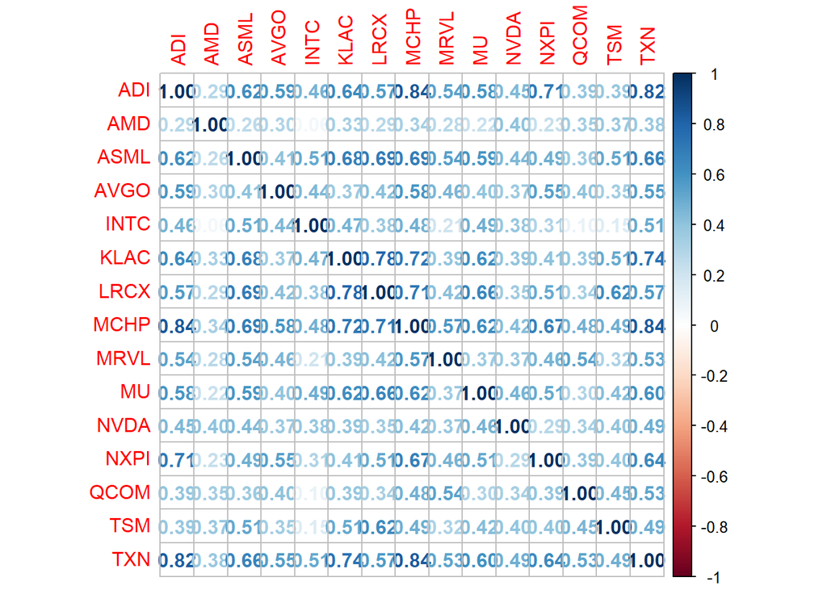

```r
# Compute the sample correlation matrix of the returns
cor_matrix <- cor(na.omit(monthly_returns))
library(corrplot)
corrplot(cor_matrix,method="number")
```

```r
#?corrplot
# Print the correlation matrix
print(cor_matrix)
```

```
##          ADI     AMD    ASML    AVGO     INTC    KLAC    LRCX    MCHP    MRVL
## ADI  1.00000 0.28743 0.61873 0.58787 0.460528 0.63753 0.56941 0.84204 0.53799
## AMD  0.28743 1.00000 0.26075 0.30272 0.058920 0.33291 0.28650 0.33648 0.27555
## ASML 0.61873 0.26075 1.00000 0.40683 0.506198 0.67794 0.69372 0.68601 0.54472
## AVGO 0.58787 0.30272 0.40683 1.00000 0.441736 0.36614 0.41942 0.58471 0.45758
## INTC 0.46053 0.05892 0.50620 0.44174 1.000000 0.46711 0.37569 0.47606 0.20937
## KLAC 0.63753 0.33291 0.67794 0.36614 0.467106 1.00000 0.78230 0.71871 0.39480
## LRCX 0.56941 0.28650 0.69372 0.41942 0.375689 0.78230 1.00000 0.71276 0.41754
## MCHP 0.84204 0.33648 0.68601 0.58471 0.476056 0.71871 0.71276 1.00000 0.57314
## MRVL 0.53799 0.27555 0.54472 0.45758 0.209368 0.39480 0.41754 0.57314 1.00000
## MU   0.58112 0.22310 0.58705 0.39600 0.488094 0.61996 0.65678 0.62152 0.36667
## NVDA 0.44761 0.40484 0.44223 0.36851 0.382564 0.39273 0.35200 0.42109 0.37128
## NXPI 0.70985 0.23024 0.48665 0.54763 0.305381 0.40942 0.50970 0.67212 0.46038
## QCOM 0.39239 0.34630 0.36184 0.40168 0.099859 0.38789 0.33657 0.47937 0.53827
## TSM  0.38562 0.37276 0.51125 0.34587 0.149929 0.50518 0.62271 0.48623 0.31944
## TXN  0.82309 0.37800 0.66054 0.55418 0.505572 0.73588 0.56634 0.83598 0.52945
##           MU    NVDA    NXPI     QCOM     TSM     TXN
## ADI  0.58112 0.44761 0.70985 0.392392 0.38562 0.82309
## AMD  0.22310 0.40484 0.23024 0.346298 0.37276 0.37800
## ASML 0.58705 0.44223 0.48665 0.361844 0.51125 0.66054
## AVGO 0.39600 0.36851 0.54763 0.401678 0.34587 0.55418
## INTC 0.48809 0.38256 0.30538 0.099859 0.14993 0.50557
## KLAC 0.61996 0.39273 0.40942 0.387889 0.50518 0.73588
## LRCX 0.65678 0.35200 0.50970 0.336573 0.62271 0.56634
## MCHP 0.62152 0.42109 0.67212 0.479375 0.48623 0.83598
## MRVL 0.36667 0.37128 0.46038 0.538267 0.31944 0.52945
## MU   1.00000 0.46251 0.50509 0.303283 0.42257 0.60003
## NVDA 0.46251 1.00000 0.28892 0.339160 0.39807 0.48933
## NXPI 0.50509 0.28892 1.00000 0.392379 0.39874 0.63650
## QCOM 0.30328 0.33916 0.39238 1.000000 0.45243 0.52626
## TSM  0.42257 0.39807 0.39874 0.452435 1.00000 0.48658
## TXN  0.60003 0.48933 0.63650 0.526260 0.48658 1.00000
```

```r
# Find the most highly correlated pair of assets
max_cor <- max(cor_matrix[upper.tri(cor_matrix)])
most_correlated <- which(cor_matrix == max_cor, arr.ind = TRUE)
# Find the least correlated pair of assets
min_cor <- min(cor_matrix[upper.tri(cor_matrix)])
least_correlated <- which(cor_matrix == min_cor, arr.ind = TRUE)
# Print the results
cat("Most highly correlated assets:", colnames(cor_matrix)[most_correlated[1]], "and", colnames(cor_matrix)[most_correlated[2]], "with correlation", max_cor, "\n")
```

```
## Most highly correlated assets: MCHP and ADI with correlation 0.84204
```

```r
cat("Least correlated assets:", colnames(cor_matrix)[least_correlated[1]], "and", colnames(cor_matrix)[least_correlated[2]], "with correlation", min_cor, "\n")
```

```
## Least correlated assets: INTC and AMD with correlation 0.05892
```

5.2 Run PCA analysis and comment: run PCA analysis comment on the result of PCA

```r
# Principal Component Analysis (PCA)
pca_result <- FactoMineR::PCA(monthly_returns, scale.unit = TRUE, ncp = ncol(monthly_returns), graph = FALSE)
#?PCA
summary(pca_result)
```

```
##
## Call:
## FactoMineR::PCA(X = monthly_returns, scale.unit = TRUE, ncp = ncol(monthly_returns),
##      graph = FALSE)
##
##
## Eigenvalues
##                        Dim.1   Dim.2   Dim.3   Dim.4   Dim.5   Dim.6   Dim.7
## Variance               7.769   1.289   1.063   0.909   0.688   0.597   0.536
## % of var.             51.795   8.592   7.090   6.060   4.588   3.978   3.571
## Cumulative % of var.  51.795  60.387  67.477  73.537  78.125  82.103  85.674
##                        Dim.8   Dim.9  Dim.10  Dim.11  Dim.12  Dim.13  Dim.14
## Variance               0.501   0.423   0.348   0.255   0.233   0.178   0.129
## % of var.              3.339   2.822   2.317   1.699   1.553   1.187   0.861
## Cumulative % of var.  89.013  91.836  94.153  95.852  97.405  98.592  99.452
##                       Dim.15
## Variance               0.082
## % of var.              0.548
## Cumulative % of var. 100.000
##
## Individuals (the 10 first)
##                Dist    Dim.1    ctr   cos2    Dim.2    ctr   cos2    Dim.3
## 2015-01-01 |  0.000 |  0.000  0.000 30.085 |  0.000  0.000  0.565 |  0.000
## 2015-02-01 |  4.018 |  3.091  1.708  0.592 |  1.058  1.207  0.069 | -1.196
## 2015-03-01 |  4.287 | -2.596  1.205  0.367 | -0.266  0.077  0.004 | -2.236
## 2015-04-01 |  2.615 | -1.185  0.251  0.205 | -1.214  1.588  0.215 |  1.226
## 2015-05-01 |  3.733 |  1.560  0.435  0.175 | -0.781  0.657  0.044 | -2.120
## 2015-06-01 |  5.189 | -4.532  3.671  0.763 |  0.780  0.656  0.023 |  0.262
## 2015-07-01 |  3.512 | -3.068  1.683  0.763 |  0.025  0.001  0.000 |  0.005
## 2015-08-01 |  3.962 | -3.301  1.948  0.694 | -0.643  0.445  0.026 | -0.279
## 2015-09-01 |  3.285 | -1.455  0.379  0.196 | -0.996  1.068  0.092 | -0.030
## 2015-10-01 |  5.415 |  3.136  1.758  0.335 | -1.161  1.452  0.046 |  2.573
##               ctr   cos2
## 2015-01-01  0.000 13.382 |
## 2015-02-01  1.867  0.089 |
## 2015-03-01  6.528  0.272 |
## 2015-04-01  1.964  0.220 |
## 2015-05-01  5.872  0.323 |
## 2015-06-01  0.090  0.003 |
## 2015-07-01  0.000  0.000 |
```

[output cut: 12 more lines]

```
## LRCX       |  0.791  8.054  0.626 | -0.125  1.211  0.016 |  0.361 12.233  0.130
## MCHP       |  0.902 10.472  0.814 | -0.075  0.435  0.006 | -0.114  1.228  0.013
## MRVL       |  0.651  5.461  0.424 |  0.284  6.241  0.080 | -0.306  8.824  0.094
## MU         |  0.743  7.105  0.552 | -0.264  5.394  0.070 |  0.186  3.256  0.035
##
## ADI        |
## AMD        |
## ASML       |
## AVGO       |
## INTC       |
## KLAC       |
## LRCX       |
## MCHP       |
## MRVL       |
## MU         |
```

### Coding Alternative for correlation and PCA (From slides)

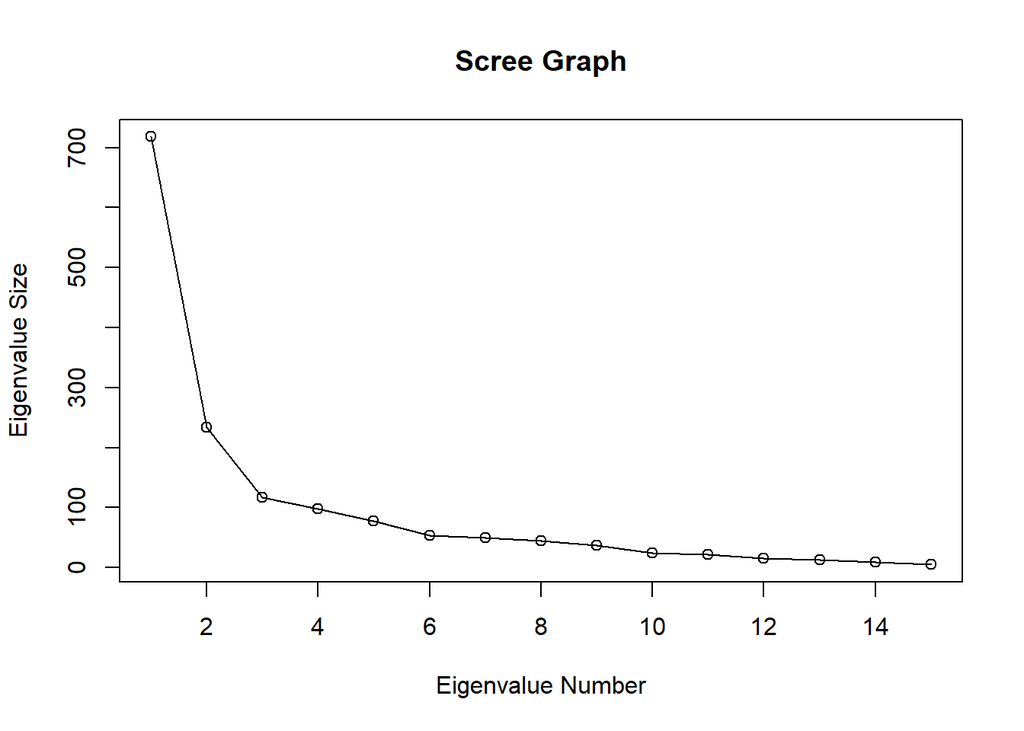

```r
#Compute the covariance matrix Z
S <- cov(na.omit(monthly_returns))
# Compute the eigen values and vectors of S
s.eigen <- eigen(S)
#s.eigen
#Make a scree graph
plot(s.eigen$values, xlab = 'Eigenvalue Number', ylab = 'Eigenvalue Size',
main = 'Scree Graph')
lines(s.eigen$values)
```

```r
# Find the principal componets
monthly_returns.pca <- prcomp(na.omit(monthly_returns))
monthly_returns.pca
```

```
## Standard deviations (1, .., p=15):
##  [1] 26.7979 15.2983 10.7882  9.8994  8.7902  7.3315  7.0544  6.6774  6.0624
## [10]  4.8667  4.6651  3.8571  3.6177  2.9332  2.2106
##
## Rotation (n x k) = (15 x 15):
##           PC1       PC2       PC3       PC4       PC5       PC6        PC7
## ADI  -0.23480  0.139355 -0.046821  0.043114 -0.288373  0.099478 -0.0020902
## AMD  -0.38417 -0.862762  0.127339  0.243501 -0.110811 -0.054354  0.1038128
## ASML -0.19461  0.118800  0.052077  0.033370  0.073775  0.245965  0.0691652
## AVGO -0.19743  0.053085 -0.142283 -0.042593 -0.364684  0.010268 -0.1191277
## INTC -0.12700  0.158650  0.203882 -0.089327 -0.187678  0.134593  0.1984352
## KLAC -0.25787  0.119799  0.139643  0.195668  0.253672  0.307211  0.1460546
## LRCX -0.28372  0.174369  0.149049  0.300802  0.310844  0.208616 -0.1723661
## MCHP -0.30357  0.159117 -0.074792  0.142154 -0.143479  0.184516  0.0376226
## MRVL -0.22572  0.056777 -0.363449 -0.151027 -0.078248  0.269440  0.4227891
## MU   -0.33557  0.272297  0.377698  0.035536  0.143188 -0.691643  0.3252939
## NVDA -0.29564 -0.091232  0.325696 -0.819003 -0.012966  0.105535 -0.2247614
## NXPI -0.25369  0.171315 -0.210163  0.161693 -0.444547 -0.309114 -0.4318749
## QCOM -0.26393 -0.061820 -0.664953 -0.232031  0.416181 -0.266100  0.0961846
## TSM  -0.20008 -0.011447 -0.022162  0.063148  0.379253  0.049246 -0.5878498
## TXN  -0.20035  0.071081 -0.045907  0.012537 -0.088806  0.074788  0.0446107
##             PC8       PC9      PC10      PC11       PC12        PC13       PC14
## ADI   0.0632091 -0.288191 -0.172924  0.305643  0.0020568  0.10784887 -0.7702203
## AMD  -0.0091988  0.007719  0.063428 -0.026010  0.0280600 -0.01010554 -0.0274345
## ASML -0.1018259  0.027032  0.447961 -0.034215  0.2210286  0.77623575  0.0698290
## AVGO  0.2861538  0.706263 -0.345922  0.035885 -0.1396707  0.23918386  0.1010152
## INTC  0.4321281  0.222187  0.597280 -0.144758  0.0606649 -0.41677569 -0.1551589
## KLAC  0.2389067 -0.222343 -0.149774 -0.114681 -0.6366543  0.02337737  0.1862096
## LRCX -0.1442614  0.182274 -0.249501 -0.496695  0.2540930 -0.12752300 -0.2486437
## MCHP  0.1026350 -0.209623 -0.209228  0.241637  0.5797269 -0.22314379  0.4471508
## MRVL -0.6322728  0.205994  0.069304  0.062077 -0.1764327 -0.22670003  0.0023876
## MU   -0.1380304  0.110351 -0.045096  0.170188 -0.0117561  0.03484865  0.0204319
## NVDA -0.0760326 -0.141005 -0.138208 -0.133112  0.0139892  0.00027205  0.0532854
## NXPI -0.1997885 -0.243580  0.238398 -0.371592 -0.1920557 -0.03926606  0.1362489
## QCOM  0.3473582 -0.075556  0.033252 -0.165154  0.1020721  0.03340531 -0.1007806
## TSM  -0.1024046  0.228125  0.271098  0.523190 -0.1100082 -0.17789191 -0.0281634
## TXN   0.1812429 -0.223168  0.056293  0.273177 -0.1741352  0.03607244  0.1939995
##            PC15
## ADI   0.1144213
## AMD   0.0068454
## ASML  0.0651952
## AVGO  0.0169909
## INTC  0.0344102
## KLAC  0.3141029
## LRCX -0.3176558
## MCHP  0.2412771
## MRVL -0.0079513
## MU    0.0253699
## NVDA  0.0095089
## NXPI  0.0716840
## QCOM  0.0285151
## TSM   0.0961294
## TXN  -0.8410514
```

```r
#Compute the correlation matrix and the principal components based on it
R <- cor(na.omit(monthly_returns))
monthly_returns.pca.scaled <- prcomp(na.omit(monthly_returns), scale = TRUE)
monthly_returns.pca.scaled
```

```
## Standard deviations (1, .., p=15):
##  [1] 2.78735 1.13524 1.03124 0.95345 0.82959 0.77242 0.73192 0.70773 0.65065
## [10] 0.58955 0.50482 0.48263 0.42195 0.35932 0.28662
##
## Rotation (n x k) = (15 x 15):
##           PC1        PC2       PC3       PC4       PC5       PC6        PC7
## ADI  -0.30490  0.1051319 -0.256016  0.036024 -0.163446  0.209718 -0.2023138
## AMD  -0.15945 -0.4924301  0.217458 -0.393375 -0.423331  0.418201  0.0994190
## ASML -0.28774  0.1386199  0.163794  0.079148  0.286497  0.068892  0.0230287
## AVGO -0.23888 -0.0447077 -0.397725 -0.192816 -0.261463 -0.398227  0.4099373
## INTC -0.19961  0.5031782 -0.065752 -0.422252  0.125230 -0.102364  0.3944161
## KLAC -0.28863  0.1411474  0.315324  0.117525  0.030451  0.319400  0.2278058
## LRCX -0.28379  0.1100230  0.349754  0.284078 -0.069013 -0.082662  0.0664230
## MCHP -0.32360  0.0659563 -0.110832  0.129252 -0.090756  0.187876  0.0096808
## MRVL -0.23370 -0.2498165 -0.297056  0.107101  0.536267  0.144697 -0.1113775
## MU   -0.26655  0.2322604  0.180455 -0.026089  0.013937 -0.144998 -0.3471247
## NVDA -0.21319 -0.1260422  0.147206 -0.628947  0.230343 -0.212387 -0.4543625
## NXPI -0.25757  0.0026128 -0.346037  0.230203 -0.368471 -0.177033 -0.3741975
## QCOM -0.20793 -0.4805088 -0.139993  0.118156  0.347226 -0.119104  0.2884739
## TSM  -0.22750 -0.2683954  0.411684  0.188954 -0.120208 -0.523890  0.0701780
## TXN  -0.31765  0.0225367 -0.111760 -0.024850 -0.049007  0.236880  0.0336025
##              PC8       PC9      PC10      PC11      PC12       PC13       PC14
## ADI   0.10677532  0.229517 -0.203345  0.145060 -0.069181 -0.2034504 -0.7304805
## AMD  -0.21905971 -0.181512  0.276512  0.025172  0.028127 -0.0618242 -0.0576558
## ASML -0.32912180  0.250780  0.376383 -0.125405 -0.667322  0.0116055 -0.0115911
## AVGO -0.27864570 -0.150920 -0.368120  0.013476 -0.289746  0.1628982  0.0467081
## INTC  0.04535706  0.027789  0.401788  0.011134  0.392091 -0.1140239 -0.1057699
## KLAC  0.15705652 -0.025505 -0.291187 -0.171834  0.128174  0.5276859 -0.1016576
## LRCX -0.24726848 -0.181757 -0.209816 -0.416179  0.191772 -0.2273783  0.0047307
## MCHP  0.05407573  0.091273 -0.158987  0.042972  0.049948 -0.6231975  0.4580457
## MRVL -0.48906403 -0.097547 -0.031784  0.233333  0.374819  0.1329447  0.0042054
## MU    0.13240233 -0.706443  0.072430  0.380448 -0.172535  0.0089075 -0.0104313
## NVDA  0.08932105  0.198630 -0.274186 -0.292133  0.020363  0.0071053  0.0874968
## NXPI  0.01586968  0.022479  0.419205 -0.380403  0.187753  0.2718915  0.0805105
## QCOM  0.53452326 -0.223016  0.154708 -0.244679 -0.099974 -0.1504086 -0.1482039
## TSM  -0.00098839  0.368925  0.091392  0.422835  0.185094  0.0066059 -0.0830482
## TXN   0.33644790  0.227027 -0.006212  0.299707 -0.074415  0.2866877  0.4316049
##            PC15
## ADI   0.1061274
## AMD   0.0102909
## ASML -0.0579003
## AVGO -0.0423783
## INTC  0.0177047
## KLAC -0.4287630
## LRCX  0.5370457
## MCHP -0.4233924
## MRVL  0.0020735
## MU   -0.0592807
## NVDA -0.0270982
## NXPI -0.1301050
## QCOM  0.0226274
## TSM  -0.1128440
## TXN   0.5451847
```

### Computing factor Analysis

5.3 factor analysis: run factor analysis, report number and loadings of each factors , find if there’s meaningful interpretation

```r
# Factor Analysis
fa_result <- factanal(factors = 3, covmat = cor_matrix)
print(fa_result)
```

```
##
## Call:
## factanal(factors = 3, covmat = cor_matrix)
##
## Uniquenesses:
##   ADI   AMD  ASML  AVGO  INTC  KLAC  LRCX  MCHP  MRVL    MU  NVDA  NXPI  QCOM
## 0.161 0.745 0.395 0.588 0.632 0.296 0.005 0.140 0.553 0.469 0.705 0.481 0.357
##   TSM   TXN
## 0.473 0.144
##
## Loadings:
##      Factor1 Factor2 Factor3
## ADI  0.824   0.322   0.238
## AMD  0.133   0.462   0.156
## ASML 0.515   0.309   0.495
## AVGO 0.492   0.367   0.187
## INTC 0.574           0.196
## KLAC 0.517   0.286   0.596
## LRCX 0.344   0.214   0.912
## MCHP 0.732   0.392   0.413
## MRVL 0.369   0.522   0.196
## MU   0.509   0.203   0.481
## NVDA 0.346   0.384   0.166
## NXPI 0.584   0.332   0.259
## QCOM 0.155   0.776   0.129
## TSM  0.138   0.493   0.515
## TXN  0.756   0.485   0.224
##
##                Factor1 Factor2 Factor3
## SS loadings      3.924   2.480   2.453
## Proportion Var   0.262   0.165   0.164
## Cumulative Var   0.262   0.427   0.590
##
## The degrees of freedom for the model is 63 and the fit was 1.2258
```

## 6. Risk Management

6.1 Parametric methods for risk management Based on $100000 investment , calculate 5% VAR and ES over one month of the assets and portfolios, based on normal distribution, using estimated means and variances . Find which asset has the highest and lowest VaR , and which asset has highest and lowest ES, over one month horizon as well as portflios.

```r
 #calculate VaR and ES (parametric, normal)
VaRnormalEqwt <- function(returnVector, prob=.05,
    notional=1, expected.return=mean(returnVector),
    digits=2)
{
  if(prob > .5) prob <- 1 - prob
  ans <- -qnorm(prob, mean=expected.return,
    sd=sd(returnVector)) * notional
  signif(ans, digits=digits)
}
ESnormalEqwt <- function(returnVector, prob=.05,
    notional=1, expected.return=mean(returnVector),
    digits=2)
{
  if(prob > .5) prob <- 1 - prob
  retsd <- sd(returnVector)
  v <- qnorm(prob, mean=expected.return, sd=retsd)
  tailExp <- integrate(function(x)
      x * dnorm(x, mean=expected.return, sd=retsd),
      -Inf, v)$value / prob
  ans <- -tailExp * notional
  signif(ans, digits=digits)
}


combined_returns_df3<- combined_returns_df[-1,-1]/100
normal_VaR_5<-sapply(combined_returns_df3 ,function(x){VaRnormalEqwt(x,prob=.05,digits=5,notional=100000)})
normal_ES_5<-sapply(combined_returns_df3 ,function(x){ESnormalEqwt(x,prob=.05,digits=5,notional=100000)})
```

6.2 nonparametric Methods for risk management use nonparametric methods, Based on $100000 investment , calculate 5% VAR and ES over one month of the assets and portfolios. Find which asset has the highest and lowest VaR , and which asset has highest and lowest ES, over one month horizon. as well as portfolios

```r
 #calculate VaR and ES (nonparametric, historical data )

VaRhistorical <- function(returnVector, prob=.05,
    notional=1, digits=2)
{
  if(prob > .5) prob <- 1 - prob
  ans <- -quantile(returnVector, prob) * notional
  signif(ans, digits=digits)
}
EShistorical <- function(returnVector, prob=.05,
    notional=1, digits=2)
{
  if(prob > .5) prob <- 1 - prob
  v <- quantile(returnVector, prob)
  ans <- -mean(returnVector[returnVector <= v]) *
      notional
  signif(ans, digits=digits)

}
combined_returns_df3<- combined_returns_df[-1,-1]/100
nonparametric_VaR_5<-sapply(combined_returns_df3 ,function(x){VaRhistorical(x,prob=.05,digits=5,notional=100000)})
nonparametric_ES_5<-sapply(combined_returns_df3 ,function(x){EShistorical(x,prob=.05,digits=5,notional=100000)})
```

```r
# Create the data frame with the updated variables
risk_measures <- data.frame(
                            Normal_VaR_5 = normal_VaR_5,
                            Normal_ES_5 = normal_ES_5,
                            Nonparametric_VaR_5 = nonparametric_VaR_5,
                            Nonparametric_ES_5 = nonparametric_ES_5)
print(risk_measures)
```

```
##        Normal_VaR_5 Normal_ES_5 Nonparametric_VaR_5 Nonparametric_ES_5
## ADI         11064.0     14376.0              9372.6            13481.0
## AMD         21457.0     28568.0             16438.0            25247.0
## ASML         8964.4     11883.0              8261.7             8676.6
## AVGO        10951.0     14401.0              9482.0            13721.0
## INTC        10604.0     13569.0             12120.0            15395.0
## KLAC        12085.0     15828.0              9779.9            13148.0
## LRCX        13139.0     17293.0             13013.0            15524.0
## MCHP        13424.0     17394.0              9122.7            17801.0
## MRVL        13378.0     17319.0             10603.0            14169.0
## MU          18025.0     23134.0             18845.0            24274.0
## NVDA        14469.0     19548.0             14683.0            22713.0
## NXPI        14893.0     19062.0             12736.0            18357.0
## QCOM        16730.0     21527.0             13812.0            18096.0
## TSM         10759.0     14214.0             10661.0            12394.0
## TXN          8451.2     11111.0              8295.5            11526.0
## X.GSPC       6125.6      7932.7              6759.1             9260.3
```

```r
#write.csv(risk_measures, "5_1 risk_measures.csv")


# Find assets with the highest and lowest VaR and ES
max_VaR <- max(risk_measures$Nonparametric_VaR_5)
min_VaR <- min(risk_measures$Nonparametric_VaR_5)
max_ES <- max(risk_measures$Nonparametric_ES_5)
min_ES <- min(risk_measures$Nonparametric_ES_5)

highest_VaR_asset <- rownames(risk_measures)[which.max(risk_measures$Nonparametric_VaR_5)]
lowest_VaR_asset <- rownames(risk_measures)[which.min(risk_measures$Nonparametric_VaR_5)]
highest_ES_asset <- rownames(risk_measures)[which.max(risk_measures$Nonparametric_ES_5)]
lowest_ES_asset <- rownames(risk_measures)[which.min(risk_measures$Nonparametric_ES_5)]
cat("Highest VaR asset at a one month horizon:", highest_VaR_asset, "with VaR", max_VaR, "\n")
```

```
## Highest VaR asset at a one month horizon: MU with VaR 18845
```

```r
cat("Lowest VaR asset at a one month horizon:", lowest_VaR_asset, "with VaR", min_VaR, "\n")
```

```
## Lowest VaR asset at a one month horizon: X.GSPC with VaR 6759.1
```

```r
cat("Highest ES asset at a one month horizon:", highest_ES_asset, "with ES", max_ES, "\n")
```

```
## Highest ES asset at a one month horizon: AMD with ES 25247
```

```r
cat("Lowest ES asset at a one month horizon:", lowest_ES_asset, "with ES", min_ES, "\n")
```

```
## Lowest ES asset at a one month horizon: ASML with ES 8676.6
```

```r
#portfolio_prt
#efficient_prt
risk_measures_port <- add_row(merge(portfolio_prt["VaR_non",], efficient_prt["VaR_non",]),
merge(portfolio_prt["ES_non",], efficient_prt["ES_non",]))
rownames(risk_measures_port) <- c("VaR_non","ES_non")
risk_measures_port<-as.data.frame(t(risk_measures_port))
risk_measures_port
```

```
##                  VaR_non  ES_non
## df_mvp_no_short  6936.20  9189.2
## df_tan_no_short  8683.00 11964.0
## df_mvp_short     5978.90  7936.8
## df_tan_short     8318.90 11709.0
## df_risky        12414.00 15694.0
## df_risky_free     813.44  1147.1
```

```r
#write.csv(risk_measures_port, "5_2 risk_measures_port.csv")

max_VaR <- max(risk_measures_port$VaR_non)
min_VaR <- min(risk_measures_port$VaR_non)
max_ES <- max(risk_measures_port$ES_non)
min_ES <- min(risk_measures_port$ES_non)

highest_VaR_port<- rownames(risk_measures_port)[which.max(risk_measures_port$VaR_non)]
lowest_VaR_port <- rownames(risk_measures_port)[which.min(risk_measures_port$VaR_non)]
highest_ES_port <- rownames(risk_measures_port)[which.max(risk_measures_port$ES_non)]
lowest_ES_port <- rownames(risk_measures_port)[which.min(risk_measures_port$ES_non)]

cat("Highest VaR portfolio at a one month horizon:", highest_VaR_port, "with VaR", max_VaR, "\n")
```

```
## Highest VaR portfolio at a one month horizon: df_risky with VaR 12414
```

```r
cat("Lowest VaR portfolio at a one month horizon:", lowest_VaR_port, "with VaR", min_VaR, "\n")
```

```
## Lowest VaR portfolio at a one month horizon: df_risky_free with VaR 813.44
```

```r
cat("Highest ES portfolio at a one month horizon:", highest_ES_port , "with ES", max_ES, "\n")
```

```
## Highest ES portfolio at a one month horizon: df_risky with ES 15694
```

```r
cat("Lowest ES portfolio at a one month horizon:", lowest_ES_port , "with ES", min_ES, "\n")
```

```
## Lowest ES portfolio at a one month horizon: df_risky_free with ES 1147.1
```

6.3 calculate Std. errors and 95% CI for 5% VaR and ES compute estimated std. errors, 95% CI for the 5% VaR and ES using bootstrap